# Experiment 3 Main Analysis

Plot (fixed effects of) models to see predictions.

```r
#model summary
mb_combined %>% summary()
```

```
##  Family: cumulative
##   Links: mu = logit; disc = identity
## Formula: ordered(AA) ~ 1 + direction * prior + conf + (1 | SubjID) + (1 | vignette)
##    Data: dc_both (Number of observations: 2300)
##   Draws: 4 chains, each with iter = 2000; warmup = 1000; thin = 1;
##          total post-warmup draws = 4000
##
## Group-Level Effects:
## ~SubjID (Number of levels: 230)
##               Estimate Est.Error l-95% CI u-95% CI Rhat Bulk_ESS Tail_ESS
## sd(Intercept)     1.47      0.09     1.29     1.66 1.00     1008     1881
##
## ~vignette (Number of levels: 10)
##               Estimate Est.Error l-95% CI u-95% CI Rhat Bulk_ESS Tail_ESS
## sd(Intercept)     0.50      0.17     0.28     0.92 1.00     1230     1748
##
## Population-Level Effects:
##                  Estimate Est.Error l-95% CI u-95% CI Rhat Bulk_ESS Tail_ESS
## Intercept[1]        -4.33      0.30    -4.91    -3.72 1.00     1487     1943
## Intercept[2]        -2.36      0.28    -2.91    -1.77 1.00     1380     1888
## Intercept[3]        -1.39      0.28    -1.93    -0.81 1.00     1364     1766
## Intercept[4]        -0.12      0.28    -0.66     0.45 1.00     1358     1846
## Intercept[5]         0.83      0.28     0.30     1.41 1.00     1373     1694
## Intercept[6]         2.56      0.29     2.01     3.15 1.00     1439     2041
## directionL          -0.75      0.35    -1.43    -0.03 1.00     1344     1546
## prior               -0.01      0.00    -0.01    -0.00 1.00     6930     3416
## conf                 0.08      0.04     0.00     0.16 1.00     2951     3137
## directionL:prior     0.00      0.00    -0.00     0.01 1.00     7090     3386
##
## Family Specific Parameters:
##      Estimate Est.Error l-95% CI u-95% CI Rhat Bulk_ESS Tail_ESS
## disc     1.00      0.00     1.00     1.00   NA       NA       NA
##
## Draws were sampled using sampling(NUTS). For each parameter, Bulk_ESS
## and Tail_ESS are effective sample size measures, and Rhat is the potential
## scale reduction factor on split chains (at convergence, Rhat = 1).
```

```r
#fixed effects in more detail
fixef(mb_combined)
```

```
##                         Estimate      Est.Error            Q2.5           Q97.5
## Intercept[1]     -4.332911995877 0.300036886598 -4.911317545755 -3.718757539537
## Intercept[2]     -2.363352405801 0.283895062290 -2.910878502480 -1.769612173986
## Intercept[3]     -1.387216162876 0.280286446215 -1.927492473329 -0.811230778010
## Intercept[4]     -0.123954773867 0.278344447944 -0.656224585732  0.448280416777
## Intercept[5]      0.829848941125 0.278454191982  0.298265508894  1.405291917919
## Intercept[6]      2.557992612209 0.286829030920  2.008043538334  3.150968825590
## directionL       -0.747268551153 0.351574659579 -1.430300222837 -0.028909551151
## prior            -0.008345639444 0.001887470010 -0.012087645454 -0.004612497125
## conf              0.082366787132 0.040633011189  0.003562284507  0.162368071124
## directionL:prior  0.003551227546 0.002443608721 -0.001096555488  0.008399190183
```

```r
#hypothesis tests
hypothesis(mb_combined, "prior < 0")
```

```
## Hypothesis Tests for class b:
##    Hypothesis Estimate Est.Error CI.Lower CI.Upper Evid.Ratio Post.Prob Star
## 1 (prior) < 0    -0.01         0    -0.01    -0.01        Inf         1    *
## ---
## 'CI': 90%-CI for one-sided and 95%-CI for two-sided hypotheses.
## '*': For one-sided hypotheses, the posterior probability exceeds 95%;
## for two-sided hypotheses, the value tested against lies outside the 95%-CI.
## Posterior probabilities of point hypotheses assume equal prior probabilities.
```

```r
hypothesis(mb_combined, "directionL < 0")
```

```
## Hypothesis Tests for class b:
##         Hypothesis Estimate Est.Error CI.Lower CI.Upper Evid.Ratio Post.Prob
## 1 (directionL) < 0    -0.75      0.35    -1.29     -0.2      43.44      0.98
##   Star
## 1    *
## ---
## 'CI': 90%-CI for one-sided and 95%-CI for two-sided hypotheses.
## '*': For one-sided hypotheses, the posterior probability exceeds 95%;
## for two-sided hypotheses, the value tested against lies outside the 95%-CI.
## Posterior probabilities of point hypotheses assume equal prior probabilities.
```

```r
hypothesis(mb_combined, "directionL:prior < 0")
```

```
## Hypothesis Tests for class b:
##               Hypothesis Estimate Est.Error CI.Lower CI.Upper Evid.Ratio
## 1 (directionL:prior) < 0        0         0        0     0.01       0.07
##   Post.Prob Star
## 1      0.07
## ---
## 'CI': 90%-CI for one-sided and 95%-CI for two-sided hypotheses.
## '*': For one-sided hypotheses, the posterior probability exceeds 95%;
## for two-sided hypotheses, the value tested against lies outside the 95%-CI.
## Posterior probabilities of point hypotheses assume equal prior probabilities.
```

```r
hypothesis(mb_combined, "conf > 0")
```

```
## Hypothesis Tests for class b:
##   Hypothesis Estimate Est.Error CI.Lower CI.Upper Evid.Ratio Post.Prob Star
## 1 (conf) > 0     0.08      0.04     0.02     0.15      51.63      0.98    *
## ---
## 'CI': 90%-CI for one-sided and 95%-CI for two-sided hypotheses.
## '*': For one-sided hypotheses, the posterior probability exceeds 95%;
## for two-sided hypotheses, the value tested against lies outside the 95%-CI.
## Posterior probabilities of point hypotheses assume equal prior probabilities.
```

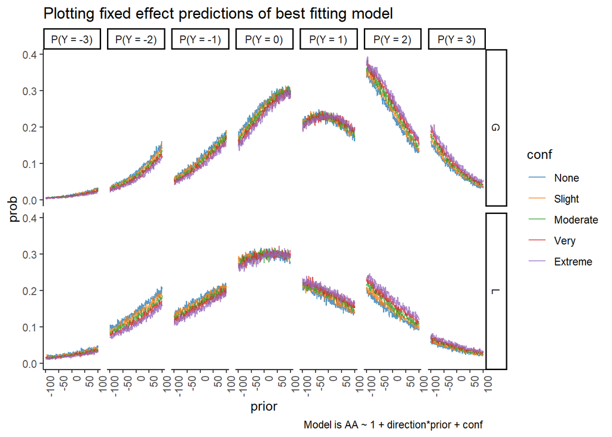

```r
#get predictions
preddat_comb <- expand.grid(prior = -100:100,
            direction = c("G", "L"),
            conf = 0:4)

preds_comb <-
  cbind(preddat_comb,
        predict(mb_combined, newdata = preddat_comb, re_formula = NA)
        ) %>%
  pivot_longer(cols = `P(Y = -3)`:`P(Y = 3)`,
               names_to = "level",
               values_to= "prob")


#still get  fuzzy estimates -- might need to remodel with larger number of iterations to improve this, but this is somehow nice, as it (inadvertently) shows some of the variance in the point estimates.

#SHOW FINAL MODEL PREDICTIONS

preds_comb %>%
  mutate(
    level = factor(level),
    level = fct_relevel(level, c("P(Y = -3)", "P(Y = -2)")),
    conf = as.character(conf)
  ) %>%
  ggplot(aes(x = prior, col = conf, y = prob)) +
  geom_line(alpha = 0.75) +
  facet_grid(direction~level) +
  theme(
    axis.text.x = element_text(angle = 90, hjust = 1),
  ) +
  scale_color_d3(breaks = 0:4, labels = c("None", "Slight", "Moderate", "Very", "Extreme")) +
  labs(
    title = "Plotting fixed effect predictions of best fitting model",
    caption = "Model is AA ~ 1 + direction*prior + conf "
  )
```

#### Frequentist

```r
## prior models
m0 <- clmm(ordered(AA) ~ 1 + (1|SubjID) + (1|vignette), dc_both)
m_dir <- clmm(ordered(AA) ~ 1 + direction + (1|SubjID) + (1|vignette), dc_both)
m_prior  <- clmm(ordered(AA) ~ 1 + prior +(1|SubjID) + (1|vignette), dc_both)
m_dir_prior  <- clmm(ordered(AA) ~ 1 + direction + prior + (1|SubjID) + (1|vignette), dc_both)
m_int  <- clmm(ordered(AA) ~ 1 + direction*prior + (1|SubjID) + (1|vignette), dc_both)

prior_mods <- list(m0, m_dir, m_prior, m_dir_prior, m_int)

map(prior_mods, ~ round(AIC(.x), 2)) %>%  print(digts = Inf)
```

```
## [[1]]
## [1] 7922.99
##
## [[2]]
## [1] 7918.02
##
## [[3]]
## [1] 7894.3
##
## [[4]]
## [1] 7890.03
##
## [[5]]
## [1] 7890.14
```

```r
#best fitting model (JUST) is direction and prior without interaction
m_dir_prior %>%  summary()
```

```
## Cumulative Link Mixed Model fitted with the Laplace approximation
##
## formula: ordered(AA) ~ 1 + direction + prior + (1 | SubjID) + (1 | vignette)
## data:    dc_both
##
##  link  threshold nobs logLik   AIC     niter     max.grad cond.H
##  logit flexible  2300 -3935.01 7890.03 708(4634) 2.04e-03 2.1e+05
##
## Random effects:
##  Groups   Name        Variance  Std.Dev.
##  SubjID   (Intercept) 2.1171961 1.4550588
##  vignette (Intercept) 0.1441474 0.3796675
## Number of groups:  SubjID 230,  vignette 10
##
## Coefficients:
##                Estimate   Std. Error  z value   Pr(>|z|)
## directionL -0.744799290  0.252662675 -2.94780  0.0032004 **
## prior      -0.006333023  0.001157585 -5.47089 4.4778e-08 ***
## ---
## Signif. codes:  0 '***' 0.001 '**' 0.01 '*' 0.05 '.' 0.1 ' ' 1
##
## Threshold coefficients:
##         Estimate Std. Error   z value
## -3|-2 -4.5126090  0.2372180 -19.02305
## -2|-1 -2.5473337  0.2118825 -12.02239
## -1|0  -1.5728420  0.2074723  -7.58097
## 0|1   -0.3117526  0.2049909  -1.52081
## 1|2    0.6380411  0.2054152   3.10611
## 2|3    2.3552797  0.2141853  10.99646
```

```r
m_int %>%  summary() # interaction model will shows strong prior effect
```

```
## Cumulative Link Mixed Model fitted with the Laplace approximation
##
## formula: ordered(AA) ~ 1 + direction * prior + (1 | SubjID) + (1 | vignette)
## data:    dc_both
##
##  link  threshold nobs logLik   AIC     niter     max.grad cond.H
##  logit flexible  2300 -3934.07 7890.14 875(5740) 6.61e-04 3.0e+05
##
## Random effects:
##  Groups   Name        Variance  Std.Dev.
##  SubjID   (Intercept) 2.1338163 1.4607588
##  vignette (Intercept) 0.1412705 0.3758597
## Number of groups:  SubjID 230,  vignette 10
##
## Coefficients:
##                      Estimate   Std. Error  z value   Pr(>|z|)
## directionL       -0.746256464  0.250374324 -2.98056  0.0028772 **
## prior            -0.008359130  0.001879164 -4.44832 8.6543e-06 ***
## directionL:prior  0.003331248  0.002429186  1.37134  0.1702680
## ---
## Signif. codes:  0 '***' 0.001 '**' 0.01 '*' 0.05 '.' 0.1 ' ' 1
##
## Threshold coefficients:
##         Estimate Std. Error   z value
## -3|-2 -4.5030967  0.2362279 -19.06251
## -2|-1 -2.5380785  0.2107938 -12.04057
## -1|0  -1.5636721  0.2063685  -7.57709
## 0|1   -0.3020868  0.2038955  -1.48158
## 1|2    0.6492982  0.2043708   3.17706
## 2|3    2.3703511  0.2133355  11.11091
```

```r
## conf models ##
m_conf  <- clmm(ordered(AA) ~ 1 + conf +(1|SubjID) + (1|vignette), dc_both)
m_dir_conf  <- clmm(ordered(AA) ~ 1 + direction + conf + (1|SubjID) + (1|vignette), dc_both)
m_confint  <- clmm(ordered(AA) ~ 1 + direction*conf + (1|SubjID) + (1|vignette), dc_both)

conf_mods <- list(m0, m_dir, m_conf, m_dir_conf, m_confint)

map_dbl(conf_mods,  ~ round(AIC(.x), 2)) %>%  print(digts = Inf)
```

```
## [1] 7922.99 7918.02 7919.81 7914.96 7915.62
```

```r
#best fitting model (JUST) is direction and conf without interaction
m_dir_conf %>%  summary()
```

```
## Cumulative Link Mixed Model fitted with the Laplace approximation
##
## formula: ordered(AA) ~ 1 + direction + conf + (1 | SubjID) + (1 | vignette)
## data:    dc_both
##
##  link  threshold nobs logLik   AIC     niter      max.grad cond.H
##  logit flexible  2300 -3947.48 7914.96 1009(7836) 5.28e-04 4.3e+02
##
## Random effects:
##  Groups   Name        Variance  Std.Dev.
##  SubjID   (Intercept) 2.0923030 1.4464795
##  vignette (Intercept) 0.1585826 0.3982243
## Number of groups:  SubjID 230,  vignette 10
##
## Coefficients:
##               Estimate  Std. Error  z value  Pr(>|z|)
## directionL -0.82621655  0.26337735 -3.13701 0.0017068 **
## conf        0.09294211  0.04129255  2.25082 0.0243969 *
## ---
## Signif. codes:  0 '***' 0.001 '**' 0.01 '*' 0.05 '.' 0.1 ' ' 1
##
## Threshold coefficients:
##         Estimate Std. Error   z value
## -3|-2 -4.3308445  0.2563242 -16.89597
## -2|-1 -2.3749890  0.2333422 -10.17814
## -1|0  -1.4096799  0.2295582  -6.14084
## 0|1   -0.1612011  0.2275281  -0.70849
## 1|2    0.7809565  0.2280388   3.42466
## 2|3    2.4915654  0.2364227  10.53861
```

```r
m_confint %>%  summary() # interaction model will shows strong prior effect
```

```
## Cumulative Link Mixed Model fitted with the Laplace approximation
##
## formula: ordered(AA) ~ 1 + direction * conf + (1 | SubjID) + (1 | vignette)
## data:    dc_both
##
##  link  threshold nobs logLik   AIC     niter      max.grad cond.H
##  logit flexible  2300 -3946.81 7915.62 1185(9263) 5.81e-03 4.6e+02
##
## Random effects:
##  Groups   Name        Variance  Std.Dev.
##  SubjID   (Intercept) 2.0960371 1.4477697
##  vignette (Intercept) 0.1599747 0.3999684
## Number of groups:  SubjID 230,  vignette 10
##
## Coefficients:
##                    Estimate  Std. Error  z value Pr(>|z|)
## directionL      -0.69238437  0.28866167 -2.39860 0.016458 *
## conf             0.12397478  0.04928775  2.51533 0.011892 *
## directionL:conf -0.07048166  0.06102406 -1.15498 0.248098
## ---
## Signif. codes:  0 '***' 0.001 '**' 0.01 '*' 0.05 '.' 0.1 ' ' 1
##
## Threshold coefficients:
##         Estimate Std. Error   z value
## -3|-2 -4.2716710  0.2618858 -16.31120
## -2|-1 -2.3144351  0.2396842  -9.65619
## -1|0  -1.3489551  0.2360471  -5.71477
## 0|1   -0.1006858  0.2340767  -0.43014
## 1|2    0.8415555  0.2346198   3.58689
## 2|3    2.5530970  0.2430250  10.50549
```

```r
## COMBINE FOR BEST FITTING MODEL?
m_combined <- clmm(ordered(AA) ~ 1 + direction + prior + conf + (1|SubjID) + (1|vignette), dc_both)

AIC(m_dir_prior)
```

```
## [1] 7890.027963
```

```r
AIC(m_combined)
```

```
## [1] 7888.278273
```

```r
## Combined model is the best
m_combined %>% summary()
```

```
## Cumulative Link Mixed Model fitted with the Laplace approximation
##
## formula: ordered(AA) ~ 1 + direction + prior + conf + (1 | SubjID) + (1 |
##     vignette)
## data:    dc_both
##
##  link  threshold nobs logLik   AIC     niter     max.grad cond.H
##  logit flexible  2300 -3933.14 7888.28 802(5263) 8.66e-02 2.4e+05
##
## Random effects:
##  Groups   Name        Variance  Std.Dev.
##  SubjID   (Intercept) 2.0912437 1.4461133
##  vignette (Intercept) 0.1444127 0.3800167
## Number of groups:  SubjID 230,  vignette 10
##
## Coefficients:
##                Estimate   Std. Error  z value  Pr(>|z|)
## directionL -0.738541782  0.252896441 -2.92033 0.0034966 **
## prior      -0.006204585  0.001159752 -5.34993 8.799e-08 ***
## conf        0.080153052  0.041374896  1.93724 0.0527162 .
## ---
## Signif. codes:  0 '***' 0.001 '**' 0.01 '*' 0.05 '.' 0.1 ' ' 1
##
## Threshold coefficients:
##         Estimate Std. Error   z value
## -3|-2 -4.3500202  0.2510969 -17.32407
## -2|-1 -2.3852107  0.2273920 -10.48942
## -1|0  -1.4104750  0.2234158  -6.31323
## 0|1   -0.1492309  0.2212842  -0.67439
## 1|2    0.8006985  0.2218104   3.60983
## 2|3    2.5193338  0.2304411  10.93266
```

```r
## ALSO GET MODEL WITH INTERACTION for paper
m_combined_int <- clmm(ordered(AA) ~ 1 + direction*prior + conf + (1|SubjID) + (1|vignette), dc_both)
m_combined_int %>% summary()
```

```
## Cumulative Link Mixed Model fitted with the Laplace approximation
##
## formula: ordered(AA) ~ 1 + direction * prior + conf + (1 | SubjID) + (1 |
##     vignette)
## data:    dc_both
##
##  link  threshold nobs logLik   AIC     niter     max.grad cond.H
##  logit flexible  2300 -3932.08 7888.17 969(6349) 1.22e-03 3.4e+05
##
## Random effects:
##  Groups   Name        Variance  Std.Dev.
##  SubjID   (Intercept) 2.1075866 1.4517529
##  vignette (Intercept) 0.1416562 0.3763724
## Number of groups:  SubjID 230,  vignette 10
##
## Coefficients:
##                      Estimate   Std. Error  z value   Pr(>|z|)
## directionL       -0.739832475  0.250705434 -2.95100  0.0031674 **
## prior            -0.008344667  0.001878629 -4.44189 8.9171e-06 ***
## conf              0.082667608  0.041449958  1.99440  0.0461089 *
## directionL:prior  0.003526675  0.002430668  1.45091  0.1468055
## ---
## Signif. codes:  0 '***' 0.001 '**' 0.01 '*' 0.05 '.' 0.1 ' ' 1
##
## Threshold coefficients:
##         Estimate Std. Error   z value
## -3|-2 -4.3347668  0.2503551 -17.31447
## -2|-1 -2.3702410  0.2265949 -10.46026
## -1|0  -1.3955900  0.2226140  -6.26910
## 0|1   -0.1338057  0.2205078  -0.60681
## 1|2    0.8178140  0.2211046   3.69877
## 2|3    2.5405123  0.2299527  11.04798
```

```r
AIC(m_combined_int)
```

```
## [1] 7888.169748
```

## Between-participants analysis

The Between participants analysis broadly replicates from our experiment 2. Both when including and when excluding vignette G1 (classic urn scenario), the best model includes only an overall intercept and paramter for vignette `direction`. In experiment 2, this was the result when excluding G1 but not when including it – perhaps by the changes made to G1 for experiment 3 (removing the introductory phrase ‘In a casino’), we reduced it as such a strongly influential outlier.

Results and graphs follow.

### Analysis Including G1

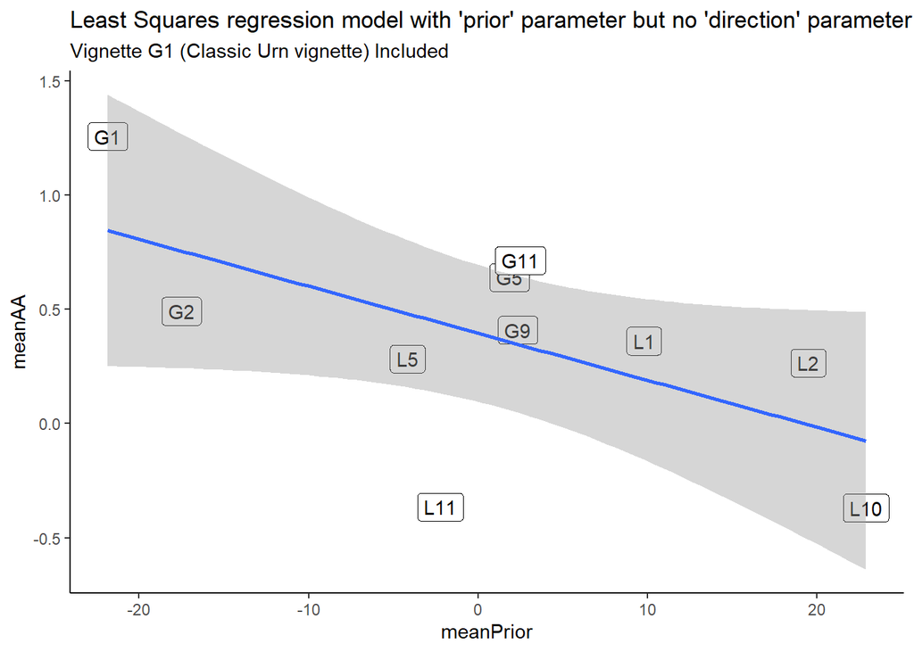

```r
d_btw <- dc_both %>%
  group_by(direction, vignette) %>%
  summarise(
    meanAA = mean(AA),
    meanPrior = mean(prior),
    meanConf = mean(conf)
  )

## plot
d_btw  %>%
  ggplot(aes(x = meanPrior, y = meanAA)) +
  geom_label(aes(label = vignette)) +
  geom_smooth(method = "lm") +
  labs(
    title = "Least Squares regression model with 'prior' parameter but no 'direction' parameter",
    subtitle = "Vignette G1 (Classic Urn vignette) Included"
  )
```

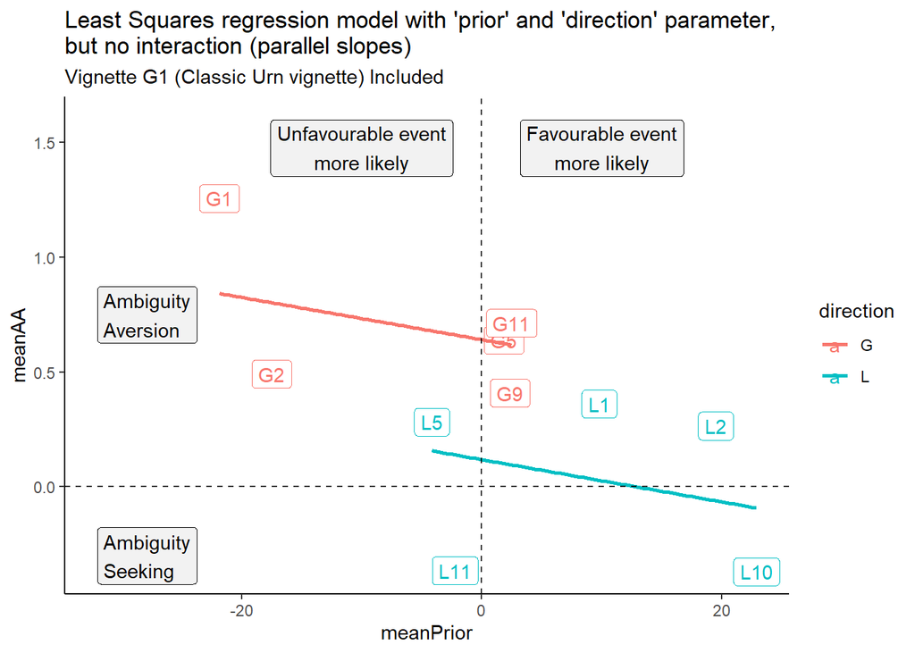

```r
d_btw  %>%
  ggplot(aes(x = meanPrior, y = meanAA, col = direction)) +
  geom_label(aes(label = vignette)) +
  moderndive::geom_parallel_slopes(method = "lm", se = FALSE, size = 1, alpha = 0.8) +
  geom_hline(yintercept = 0, linetype = 2, alpha = .8) +
  geom_vline(xintercept = 0, linetype = 2, alpha = .8) +
  annotate(geom = "label", label = "Unfavourable event\nmore likely", x = -10, y = 1.6, fill = "gray95", vjust = "inward") +
  annotate(geom = "label", label = "Favourable event\nmore likely", x = 10, y = 1.6, fill = "gray95", vjust = "inward") +
  annotate(geom = "label", label = "Ambiguity\nAversion", x = -32, y = .75, fill = "gray95", hjust = "inward") +
  annotate(geom = "label", label = "Ambiguity\nSeeking", x = -32, y = -0.3, fill = "gray95", hjust = "inward") +
  labs(
    title = "Least Squares regression model with 'prior' and 'direction' parameter,\nbut no interaction (parallel slopes)",
    subtitle = "Vignette G1 (Classic Urn vignette) Included"
  )
```

```r
### compare models
btw_mods <- list()

btw_mods[[1]] <- lm(meanAA ~ 1, data = d_btw)
btw_mods[[2]] <- lm(meanAA ~ 1 + direction, data = d_btw)
btw_mods[[3]] <- lm(meanAA ~ 1 + meanPrior, data = d_btw)
btw_mods[[4]] <- lm(meanAA ~ 1 + direction + meanPrior, data = d_btw)
btw_mods[[5]] <- lm(meanAA ~ 1 + direction*meanPrior, data = d_btw)
btw_mods[[6]] <- lm(meanAA ~ 1 + meanConf, data = d_btw)
btw_mods[[7]] <- lm(meanAA ~ 1 + direction + meanConf, data = d_btw)
btw_mods[[8]] <- lm(meanAA ~ 1 + direction*meanConf, data = d_btw)
btw_mods[[9]] <- lm(meanAA ~ 1 + direction + meanPrior + meanConf, data = d_btw)
btw_mods[[10]] <- lm(meanAA ~ 1 + direction* meanPrior + meanConf, data = d_btw)


# show table
tibble(
  formula = map_chr(btw_mods, function(x) as.character(x$call)[2]),
  AIC_value = map_dbl(btw_mods, ~round(AIC(.x), 2)),
  AIC_weight = qpcR::akaike.weights(AIC_value)$weights %>% round(2)
) %>%
  flextable::flextable() %>%
  ftExtra::span_header() %>%
  flextable::set_caption("AIC values and AIC weights for between participant models") %>%
  autofit()
```

AIC values and AIC weights for between participant models

| formula | AIC value | AIC weight |
| --- | --- | --- |
| meanAA ~ 1 | 16.76 | 0.02 |
| meanAA ~ 1 + direction | 11.22 | 0.32 |
| meanAA ~ 1 + meanPrior | 14.25 | 0.07 |
| meanAA ~ 1 + direction + meanPrior | 12.14 | 0.20 |
| meanAA ~ 1 + direction * meanPrior | 13.57 | 0.10 |
| meanAA ~ 1 + meanConf | 18.16 | 0.01 |
| meanAA ~ 1 + direction + meanConf | 13.17 | 0.12 |
| meanAA ~ 1 + direction * meanConf | 15.06 | 0.05 |
| meanAA ~ 1 + direction + meanPrior + meanConf | 14.11 | 0.08 |
| meanAA ~ 1 + direction * meanPrior + meanConf | 15.56 | 0.04 |

### Analysis Excluding G1

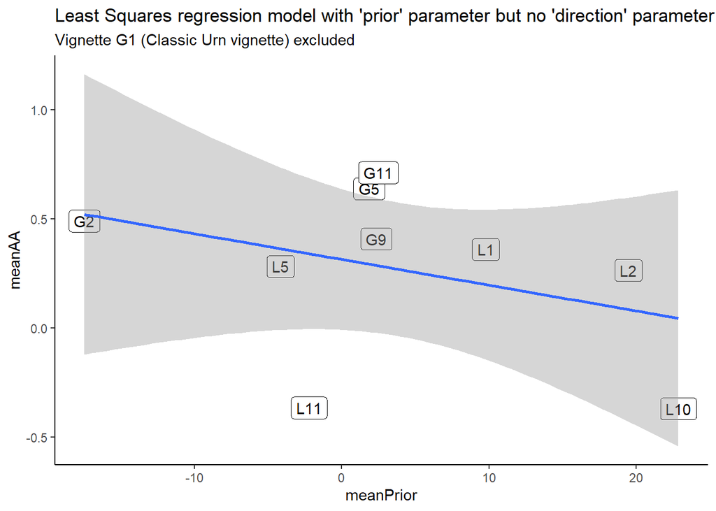

```r
## Now when remove G1
d_btw_nG1 <- d_btw %>%
  filter(vignette != "G1")

## plot
d_btw_nG1  %>%
  ggplot(aes(x = meanPrior, y = meanAA)) +
  geom_label(aes(label = vignette)) +
  geom_smooth(method = "lm") +
  labs(
    title = "Least Squares regression model with 'prior' parameter but no 'direction' parameter",
    subtitle = "Vignette G1 (Classic Urn vignette) excluded"
  )
```

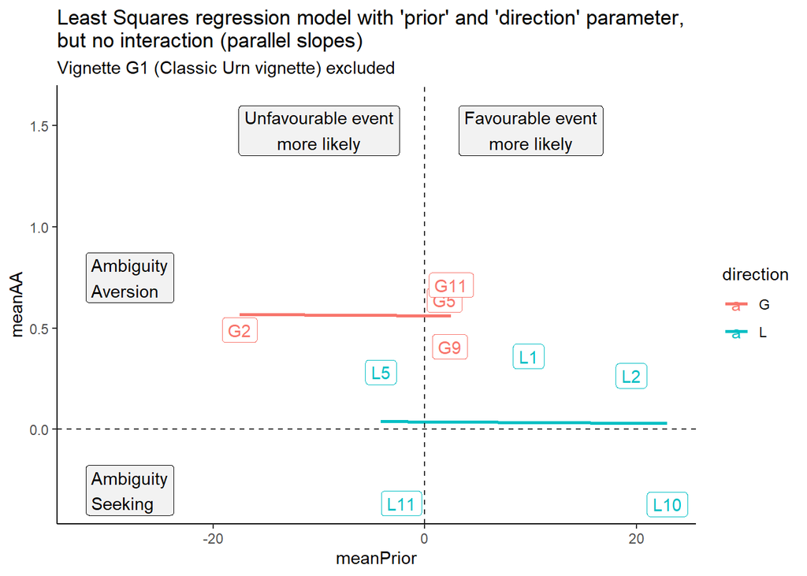

```r
d_btw_nG1  %>%
  ggplot(aes(x = meanPrior, y = meanAA, col = direction)) +
  geom_label(aes(label = vignette)) +
  moderndive::geom_parallel_slopes(method = "lm", se = FALSE, size = 1, alpha = 0.8) +
  geom_hline(yintercept = 0, linetype = 2, alpha = .8) +
  geom_vline(xintercept = 0, linetype = 2, alpha = .8) +
  annotate(geom = "label", label = "Unfavourable event\nmore likely", x = -10, y = 1.6, fill = "gray95", vjust = "inward") +
  annotate(geom = "label", label = "Favourable event\nmore likely", x = 10, y = 1.6, fill = "gray95", vjust = "inward") +
  annotate(geom = "label", label = "Ambiguity\nAversion", x = -32, y = .75, fill = "gray95", hjust = "inward") +
  annotate(geom = "label", label = "Ambiguity\nSeeking", x = -32, y = -0.3, fill = "gray95", hjust = "inward") +
  labs(
    title = "Least Squares regression model with 'prior' and 'direction' parameter,\nbut no interaction (parallel slopes)",
    subtitle = "Vignette G1 (Classic Urn vignette) excluded"
  )
```

```r
## Models
btw_mods_nG1 <- list()

btw_mods_nG1[[1]] <- lm(meanAA ~ 1, data = d_btw_nG1)
btw_mods_nG1[[2]] <- lm(meanAA ~ 1 + direction, data = d_btw_nG1)
btw_mods_nG1[[3]] <- lm(meanAA ~ 1 + meanPrior, data = d_btw_nG1)
btw_mods_nG1[[4]] <- lm(meanAA ~ 1 + direction + meanPrior, data = d_btw_nG1)
btw_mods_nG1[[5]] <- lm(meanAA ~ 1 + direction*meanPrior, data = d_btw_nG1)
btw_mods_nG1[[6]] <- lm(meanAA ~ 1 + meanConf, data = d_btw_nG1)
btw_mods_nG1[[7]] <- lm(meanAA ~ 1 + direction + meanConf, data = d_btw_nG1)
btw_mods_nG1[[8]] <- lm(meanAA ~ 1 + direction*meanConf, data = d_btw_nG1)
btw_mods_nG1[[9]] <- lm(meanAA ~ 1 + direction + meanPrior + meanConf, data = d_btw_nG1)
btw_mods_nG1[[10]] <- lm(meanAA ~ 1 + direction*meanPrior + meanConf, data = d_btw_nG1)

# show table
tibble(
  formula = map_chr(btw_mods_nG1, function(x) as.character(x$call)[2]),
  AIC_value = map_dbl(btw_mods_nG1, ~round(AIC(.x), 2)),
  AIC_weight = qpcR::akaike.weights(AIC_value)$weights %>% round(2)
) %>%
  flextable::flextable() %>%
  ftExtra::span_header() %>%
  flextable::set_caption("AIC values and AIC weights for between participant models excluding G1") %>%
  autofit()
```

AIC values and AIC weights for between participant models excluding G1

| formula | AIC value | AIC weight |
| --- | --- | --- |
| meanAA ~ 1 | 11.57 | 0.04 |
| meanAA ~ 1 + direction | 7.19 | 0.39 |
| meanAA ~ 1 + meanPrior | 12.24 | 0.03 |
| meanAA ~ 1 + direction + meanPrior | 9.19 | 0.15 |
| meanAA ~ 1 + direction * meanPrior | 11.02 | 0.06 |
| meanAA ~ 1 + meanConf | 12.78 | 0.02 |
| meanAA ~ 1 + direction + meanConf | 9.02 | 0.16 |
| meanAA ~ 1 + direction * meanConf | 10.98 | 0.06 |
| meanAA ~ 1 + direction + meanPrior + meanConf | 11.02 | 0.06 |
| meanAA ~ 1 + direction * meanPrior + meanConf | 12.50 | 0.03 |

## Lost to follow up (LTFU) analysis

There is some evidence that there is a small effect, with those lost to follow up rating the vignette priors to be 2.63 points more favourable than those with followup in the frequentist analysis. However, the Bayesian analysis preferred the null model. Thus, likely indicating that if selection effects exist, they are minor.

### Frequentist modeling

```r
m0 <- lmer(prior ~ 1 + (1|SubjID) + (1|vignette), dc_pass)
m_ltfu <- lmer(prior ~ 1 + LTFU + (1|SubjID) + (1|vignette), dc_pass)

AIC(m0)
```

```
## [1] 26760.47556
```

```r
AIC(m_ltfu)
```

```
## [1] 26757.59652
```

```r
summary(m0)
```

```
## Linear mixed model fit by REML ['lmerMod']
## Formula: prior ~ 1 + (1 | SubjID) + (1 | vignette)
##    Data: dc_pass
##
## REML criterion at convergence: 26752.5
##
## Scaled residuals:
##        Min         1Q     Median         3Q        Max
## -3.4037122 -0.4964839 -0.0579053  0.5037522  3.5319602
##
## Random effects:
##  Groups   Name        Variance   Std.Dev.
##  SubjID   (Intercept)   24.73661  4.973591
##  vignette (Intercept)  172.65522 13.139833
##  Residual             1229.82732 35.068894
## Number of obs: 2680, groups:  SubjID, 268; vignette, 10
##
## Fixed effects:
##             Estimate Std. Error t value
## (Intercept) 1.682836   4.220985 0.39868
```

```r
summary(m_ltfu)
```

```
## Linear mixed model fit by REML ['lmerMod']
## Formula: prior ~ 1 + LTFU + (1 | SubjID) + (1 | vignette)
##    Data: dc_pass
##
## REML criterion at convergence: 26747.6
##
## Scaled residuals:
##        Min         1Q     Median         3Q        Max
## -3.4573078 -0.4923326 -0.0554681  0.5051163  3.5398136
##
## Random effects:
##  Groups   Name        Variance   Std.Dev.
##  SubjID   (Intercept)   24.44262  4.943948
##  vignette (Intercept)  172.65799 13.139939
##  Residual             1229.82697 35.068889
## Number of obs: 2680, groups:  SubjID, 268; vignette, 10
##
## Fixed effects:
##             Estimate Std. Error t value
## (Intercept) 1.309565   4.231640 0.30947
## LTFUTRUE    2.632540   2.126169 1.23816
##
## Correlation of Fixed Effects:
##          (Intr)
## LTFUTRUE -0.071
```

### Bayesian modeling

```r
#bayes
m0_bayes <- brm(prior ~ 1 + (1|SubjID) + (1|vignette),
                data = dc_pass,
                cores = 4,
                #refresh = 0, open_progress = FALSE,
                seed = 3838
                )

m_ltfu_bayes <- brm(prior ~ 1 + LTFU + (1|SubjID) + (1|vignette),
                  data = dc_pass,
                  cores = 4,
                  #refresh = 0, open_progress = FALSE,
                  seed = 3838
                  )

# Save to file so don't have to reanalyse
save(m0_bayes, m_ltfu_bayes,
     file = "bayesmods_LTFU.Rdata")
```

```r
# load models, but don't error if they don't exist
try(
 load(file = "bayesmods_LTFU.Rdata"),
 silent = TRUE
)

m0_bayes %>%  summary()
```

```
##  Family: gaussian
##   Links: mu = identity; sigma = identity
## Formula: prior ~ 1 + (1 | SubjID) + (1 | vignette)
##    Data: dc_pass (Number of observations: 2680)
##   Draws: 4 chains, each with iter = 2000; warmup = 1000; thin = 1;
##          total post-warmup draws = 4000
##
## Group-Level Effects:
## ~SubjID (Number of levels: 268)
##               Estimate Est.Error l-95% CI u-95% CI Rhat Bulk_ESS Tail_ESS
## sd(Intercept)     4.20      1.61     0.61     6.92 1.00      693      662
##
## ~vignette (Number of levels: 10)
##               Estimate Est.Error l-95% CI u-95% CI Rhat Bulk_ESS Tail_ESS
## sd(Intercept)    12.91      2.96     8.54    20.04 1.00     1595     2188
##
## Population-Level Effects:
##           Estimate Est.Error l-95% CI u-95% CI Rhat Bulk_ESS Tail_ESS
## Intercept     1.00      3.31    -5.60     7.47 1.00     1213     1844
##
## Family Specific Parameters:
##       Estimate Est.Error l-95% CI u-95% CI Rhat Bulk_ESS Tail_ESS
## sigma    35.13      0.51    34.15    36.14 1.00     3928     2563
##
## Draws were sampled using sampling(NUTS). For each parameter, Bulk_ESS
## and Tail_ESS are effective sample size measures, and Rhat is the potential
## scale reduction factor on split chains (at convergence, Rhat = 1).
```

```r
m_ltfu_bayes %>%  summary()
```

```
##  Family: gaussian
##   Links: mu = identity; sigma = identity
## Formula: prior ~ 1 + LTFU + (1 | SubjID) + (1 | vignette)
##    Data: dc_pass (Number of observations: 2680)
##   Draws: 4 chains, each with iter = 2000; warmup = 1000; thin = 1;
##          total post-warmup draws = 4000
##
## Group-Level Effects:
## ~SubjID (Number of levels: 268)
##               Estimate Est.Error l-95% CI u-95% CI Rhat Bulk_ESS Tail_ESS
## sd(Intercept)     4.10      1.65     0.47     6.93 1.00      677      669
##
## ~vignette (Number of levels: 10)
##               Estimate Est.Error l-95% CI u-95% CI Rhat Bulk_ESS Tail_ESS
## sd(Intercept)    12.85      2.96     8.52    19.98 1.00     1809     2560
##
## Population-Level Effects:
##           Estimate Est.Error l-95% CI u-95% CI Rhat Bulk_ESS Tail_ESS
## Intercept     0.81      3.39    -5.96     7.56 1.00     1309     1747
## LTFUTRUE      2.64      2.11    -1.49     6.63 1.00     8484     3121
##
## Family Specific Parameters:
##       Estimate Est.Error l-95% CI u-95% CI Rhat Bulk_ESS Tail_ESS
## sigma    35.14      0.51    34.15    36.13 1.00     4953     2774
##
## Draws were sampled using sampling(NUTS). For each parameter, Bulk_ESS
## and Tail_ESS are effective sample size measures, and Rhat is the potential
## scale reduction factor on split chains (at convergence, Rhat = 1).
```

```r
##LOO COMPARE
loo(m0_bayes)
```

```
##
## Computed from 4000 by 2680 log-likelihood matrix
##
##          Estimate   SE
## elpd_loo -13367.8 46.0
## p_loo        50.4  1.9
## looic     26735.6 91.9
## ------
## Monte Carlo SE of elpd_loo is 0.1.
##
## All Pareto k estimates are good (k < 0.5).
## See help('pareto-k-diagnostic') for details.
```

```r
loo(m_ltfu_bayes)
```

```
##
## Computed from 4000 by 2680 log-likelihood matrix
##
##          Estimate   SE
## elpd_loo -13368.4 45.9
## p_loo        50.2  1.8
## looic     26736.7 91.9
## ------
## Monte Carlo SE of elpd_loo is 0.1.
##
## All Pareto k estimates are good (k < 0.5).
## See help('pareto-k-diagnostic') for details.
```

## Do order effects affect main relationship between priors and AA?

There were order effects which could have given artificially given rise to the main finding of a negative relationship between favourable priors and ambiguity aversion (as later trials had more favourable priors and less ambiguity aversion – so each timepoints individual analysis). The following graphical analysis renders this hypothesis unlikely.

The following graphs, illustrate that this negative relationship persisted for all trial positions when considering trial position for the AA and prior ratings univariately.

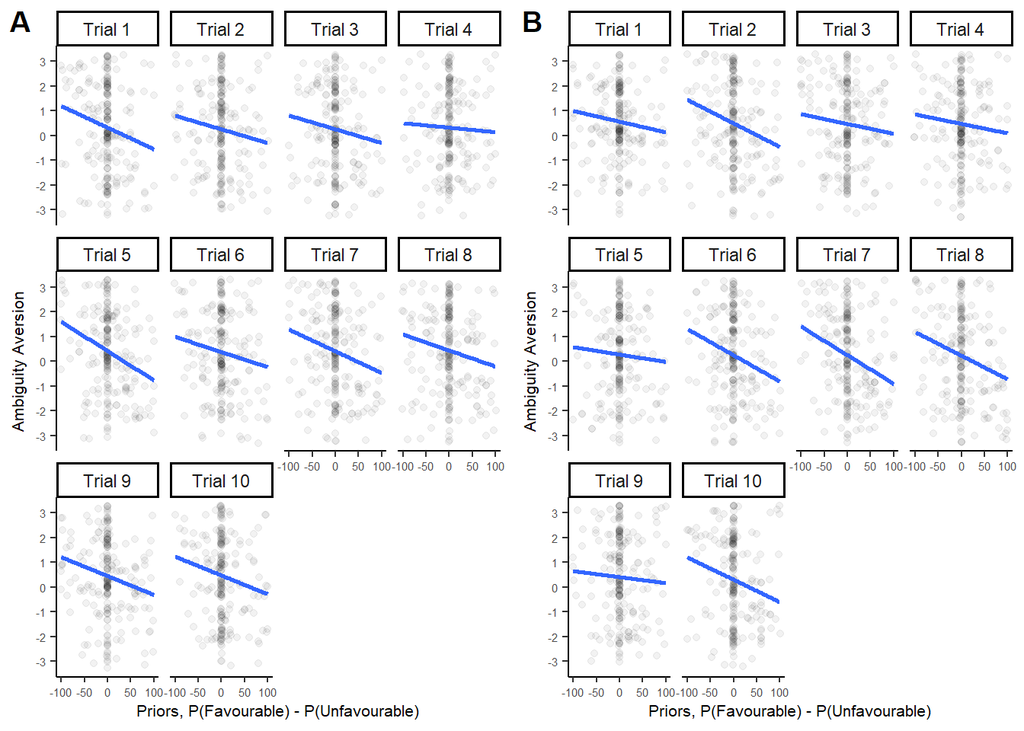

```r
rel_t1 <- dc_both %>%
  mutate(
    trialn = paste("Trial", trialn) %>% fct_relevel("Trial 10", after = Inf)
  ) %>%
  ggplot(aes(x = prior, y = AA)) +
  geom_jitter(alpha = 0.05) +
  geom_smooth(method = "lm", se = FALSE) +
  facet_wrap(~trialn) +
  labs(
    #title = "checking the relationship between prior and AA\nfor different trial positions for prior rating"
    x = "Priors, P(Favourable) - P(Unfavourable)",
    y = "Ambiguity Aversion"
  )  +
  scale_y_continuous(breaks = -3:3, minor_breaks = NULL, limits = (c(-3.30,3.30))) +
    theme(
      axis.text = element_text(size = 5.5),
      axis.title = element_text(size = 8)
      )


rel_t2 <- dc_both %>%
  mutate(
    trialn_t2 = paste("Trial", trialn_t2) %>% fct_relevel("Trial 10", after = Inf)
  ) %>%
  ggplot(aes(x = prior, y = AA)) +
  geom_jitter(alpha = 0.05) +
  geom_smooth(method = "lm", se = FALSE) +
  facet_wrap(~trialn_t2) +
  labs(
    #title = "checking the relationship between prior and AA\nfor different trial positions for AA rating"
    x = "Priors, P(Favourable) - P(Unfavourable)",
    y = "Ambiguity Aversion"
  )  +
  scale_y_continuous(breaks = -3:3, minor_breaks = NULL, limits = (c(-3.30,3.30))) +
    theme(
      axis.text = element_text(size = 5.5),
      axis.title = element_text(size = 8)
      )



cowplot::plot_grid(rel_t1, rel_t2,labels = "AUTO", nrow = 1)
```

```r
ggsave("fig-7.png", width = 7, height = 3.5)
```

In addition, the effect persisted in a majority of cases when conditioning on both the AA and prior rating bivariately (however, note, here than sample sizes are small, so more noise is to be expected between position-groups given law of large numbers), and without a clear pattern (which would be expected if relationship was an artifact of trial positions) in which the relationship is much more likely for late-AA-trial-position/late-prior-trial-position combinations, much less likely for early-AA-trial-position/early-prior-trial-position combinations, and middling for other position combinations. Thus, it appears that the effect is NOT a mere artifact of the order in our experimental design.

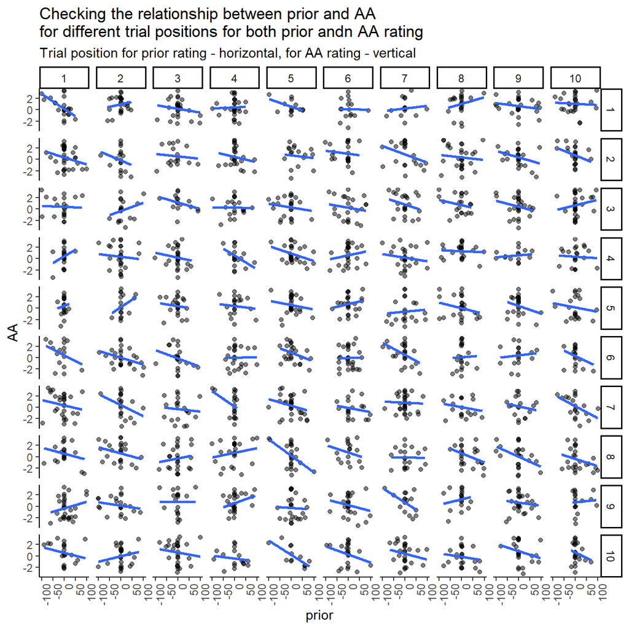

```r
dc_both %>%
  ggplot(aes(x = prior, y = AA)) +
  geom_jitter(alpha =  0.5) +
  geom_smooth(method = "lm", se = FALSE) +
  facet_grid(trialn_t2~trialn) +
  labs(
    title = "Checking the relationship between prior and AA\nfor different trial positions for both prior andn AA rating",
    subtitle = "Trial position for prior rating - horizontal, for AA rating - vertical"
  ) +
  theme(
    axis.text.x = element_text(angle = 90, hjust = 1)
  )
```